# Meeting 2 - R Programming and Data Visualizatoin

### Visualizing relationships between two variables

Now, let’s make an x-y scatter plot. Specifically, we would like to plot Sepal.Length versus Petal.Length.

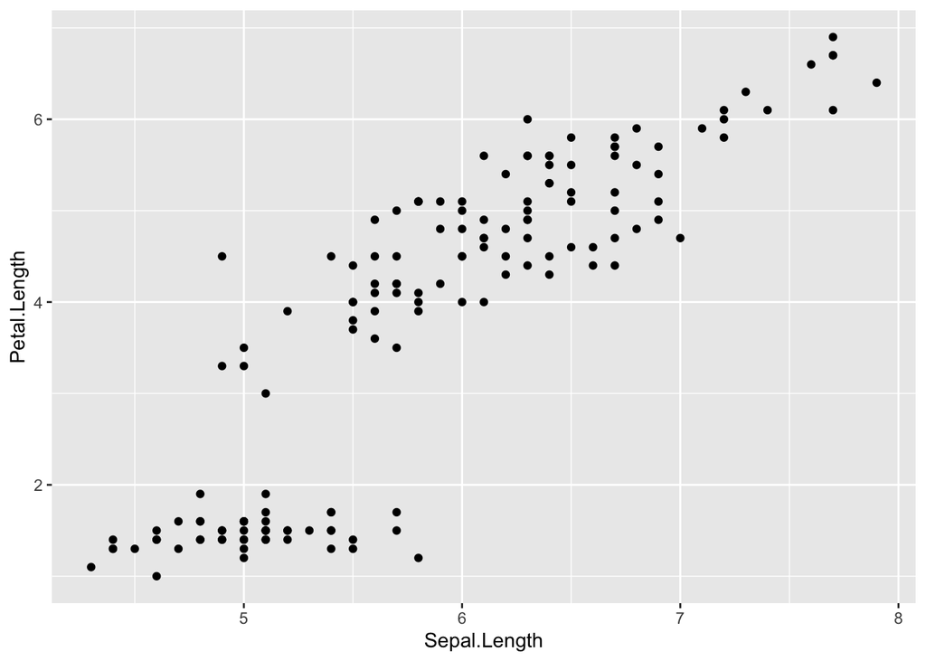

```r
ggplot(data = iris_full, aes( x = Sepal.Length, y = Petal.Length )) +
  geom_point(  )
```

**THAT SEEMS SO COMPLICATED!**

It’s true. The syntax for ggplot can seem pretty complicated. But the power of ggplot lies in the ability to lay several geometries (geoms) over each other. Also, each geometry has a rich set of options. For example, let’s say I want to create the plot we just made, but have each species represented by a different color.

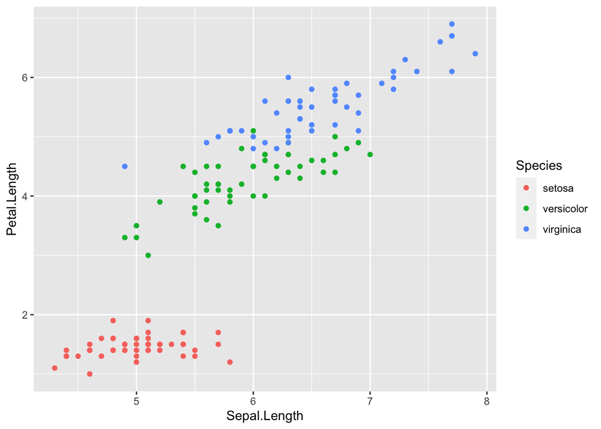

```r
ggplot(data = iris_full, aes( x = Sepal.Length, y = Petal.Length, colour = Species ) ) +
  geom_point( )
```

Let’s add more information - how about habitat type as well.

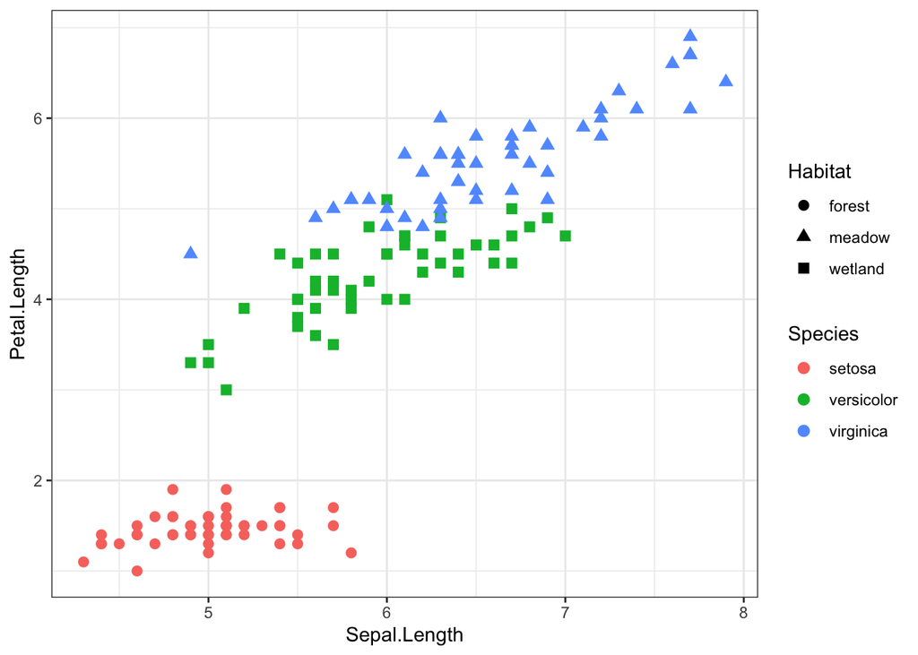

```r
ggplot(data = iris_full, aes( x = Sepal.Length, y = Petal.Length, colour = Species, shape = Habitat)) +
  geom_point(size = 2.5 ) +
  theme_bw()
```

How about if we wanted to add trend lines.

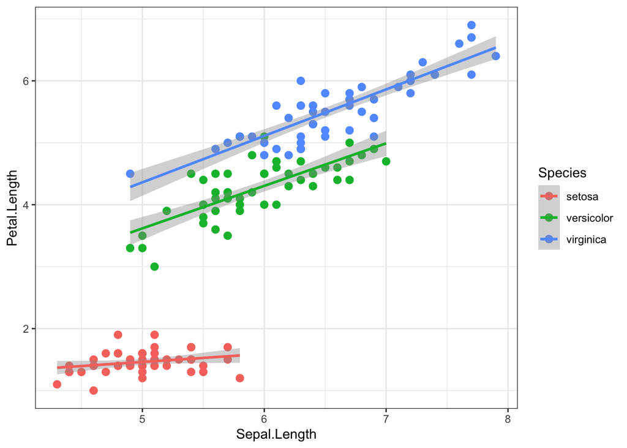

```r
ggplot(data = iris_full, aes( x = Sepal.Length, y = Petal.Length, colour = Species)) +
  geom_point(size = 2.5 ) +
  geom_smooth(method = "lm") +
  theme_bw()
```

**facets** - a way to separate data into different subplots

Let’s say we wanted different plots for each species. We can do that in ggplot using `facets`.

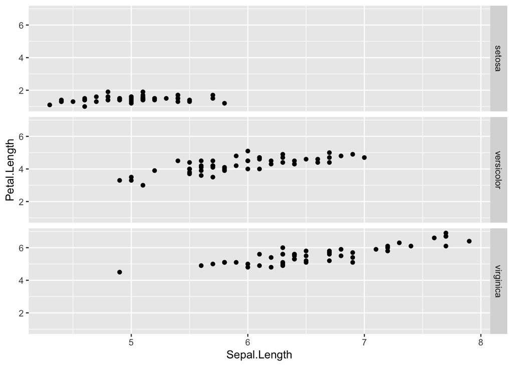

```r
ggplot( data = iris_full, aes( x = Sepal.Length, y = Petal.Length ) ) +
  geom_point() +
  facet_grid( Species ~ . )
```

#### Challenge

1. `ggplot2` has many geometries, allowing us to make lot’s of different types of plots. Let’s make two new plots - one **boxplot** of `Petal.Length`, with one boxplot for each species. Use `geom_boxplot` for this.

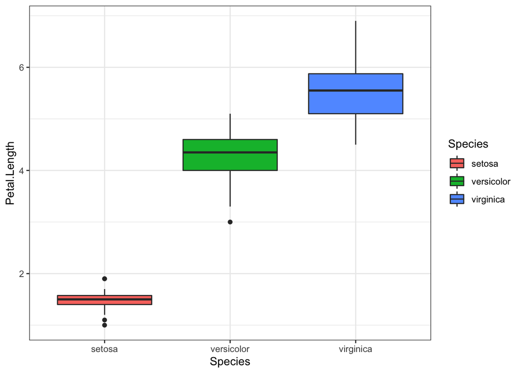

```r
ggplot(data = iris_full, aes(x = Species, y = Petal.Length, fill = Species)) +
  geom_boxplot() +
  theme_bw()
```

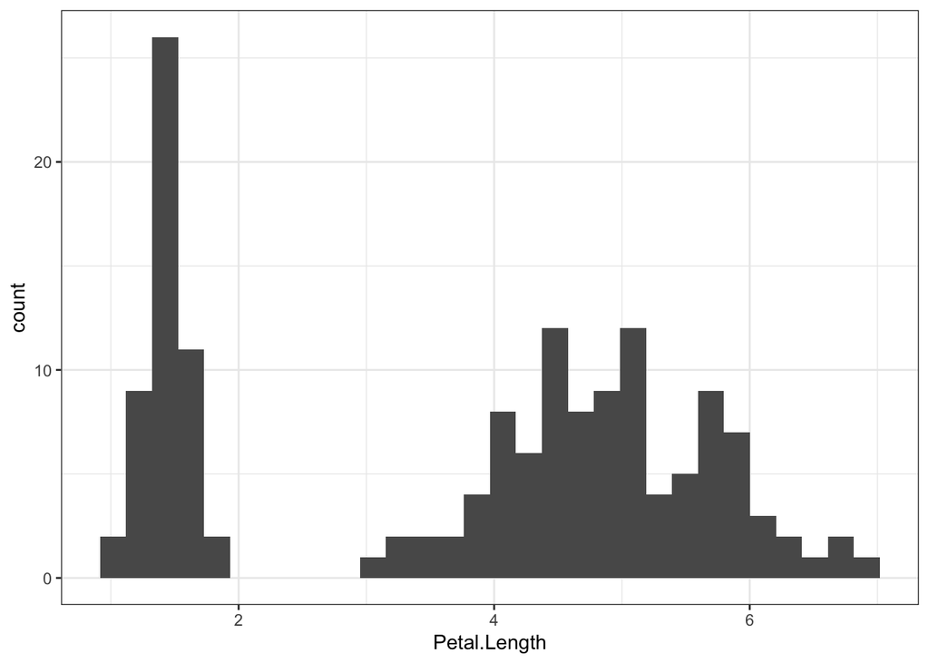

```r
ggplot(data = iris_full, aes(x = Petal.Length)) +
  geom_histogram() +
  theme_bw()
```

Use facets to separate the three species.

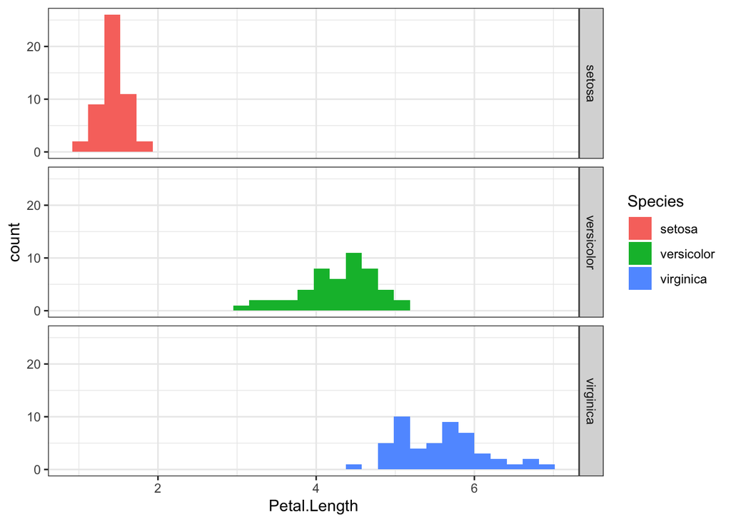

```r
ggplot(data = iris_full, aes(x = Petal.Length, fill = Species)) +
  geom_histogram() +
  facet_grid( Species ~ . ) +
  theme_bw()
```

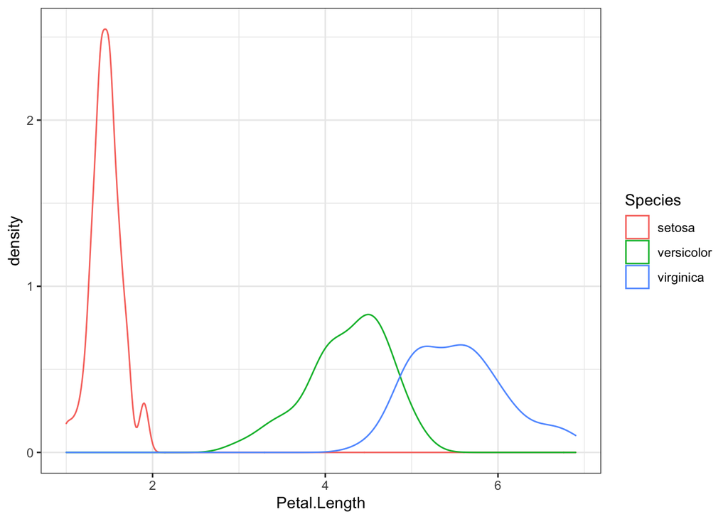

```r
ggplot(data = iris_full, aes(x = Petal.Length, colour = Species)) +
  geom_density() +
  theme_bw()
```

4. Use histogram to plot density instead of counts.

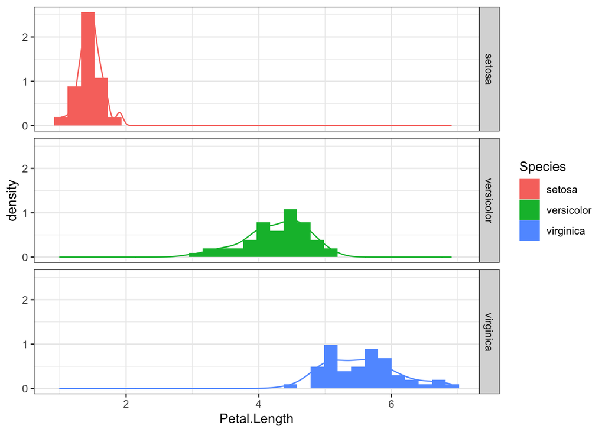

```r
ggplot(data = iris_full, aes(x = Petal.Length)) +
  geom_histogram(aes(y = ..density.., fill = Species)) +
  facet_grid( Species ~ . ) +
  geom_density(aes(colour = Species)) +
  theme_bw()
```

### More `ggplot2` resources

- http://docs.ggplot2.org/current/: The official **ggplot2** documentation.
- http://www.amazon.com/o/ASIN/0387981403/ref=nosim/gettgenedone-20: The **ggplot2** book, by the developer, Hadley Wickham.
- https://groups.google.com/forum/#!forum/ggplot2: The **ggplot2** Google Group (mailing list, discussion forum).
- https://github.com/swcarpentry/bc/tree/master/intermediate/r/data-visualization: Intermediate Software Carpentry lesson on data visualization with **ggplot2**.
- http://learnr.wordpress.com/: A blog with a good number of posts describing how to reproduce various kind of plots using **ggplot2**.
- http://stackoverflow.com/questions/tagged/ggplot2: Thousands of questions and answers tagged with “ggplot2” on Stack Overflow, a programming Q&A site.